# Projekt 1 - EDA

Michał Stawikowski, Adam Rydelek, Witold Merkel

17 - 03 - 2019

# 1 Wprowadzenie

Celem tego raportu jest przeprowadzenie eksploracyjnej analizy danych na zbiorze `Compass`.

# 2 Przedstawienie danych

## 2.1 Surowe dane

| rows | 18316 |
| --- | --- |
| columns | 20 |
| discrete_columns | 14 |
| continuous_columns | 6 |
| all_missing_columns | 0 |
| total_missing_values | 24713 |
| complete_rows | 0 |
| total_observations | 366320 |
| memory_usage | 5530120 |

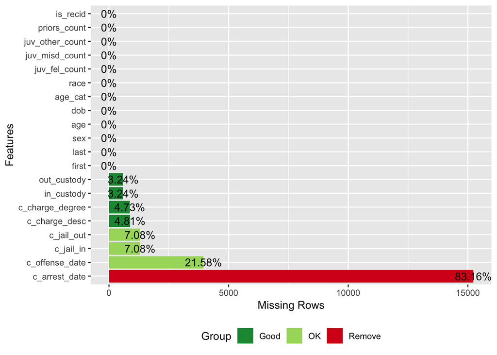

Jak widzimy z powyższego wykresu w pierwotnej ramce danych ograniczonej do interesujących nas zmiennych, nie występuje ani jeden kompletny rekord, wysoki jest też wskaźnik brakujących danych.

## 2.2 Obrobione dane

| rows | 10331 |
| --- | --- |
| columns | 21 |
| discrete_columns | 11 |
| continuous_columns | 10 |
| all_missing_columns | 0 |
| total_missing_values | 1712 |
| complete_rows | 9895 |
| total_observations | 216951 |
| memory_usage | 2724096 |

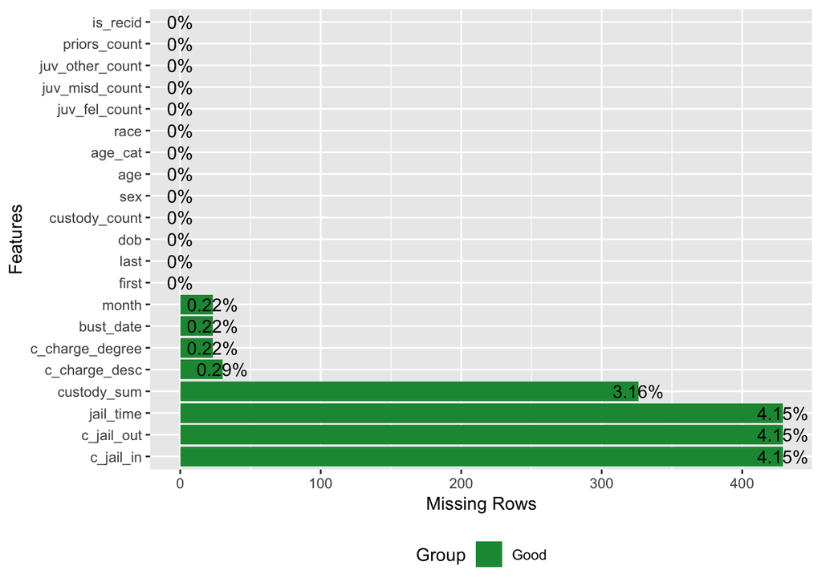

Po obróbce widać spadek braku danych, a także nowo dodane kolumny, które stworzyliśmy na potrzeby lepszego zrozumienia i wizualizacji zależności pomiędzy zmiennymi, a także analizy samych zmiennych. Nowo dodanymi kolumnami są:

- `custody_count` - opisująca ilość odsiadek w areszcie
- `custody_sum` - zawierająca ilość dni spędzonych w areszcie
- `jail_time` - mówiąca nam ile dni przestępca spędził w więzioniu
- `bust_date` - zmienna stworzona przez scalenie dwóch bardzo niekompletnych kolumn w jedną, dzięki czemu uzyskaliśmy przybliżoną datę zatrzymania przestępcy

# 3 Podstawowa analiza

## 3.1 Struktura

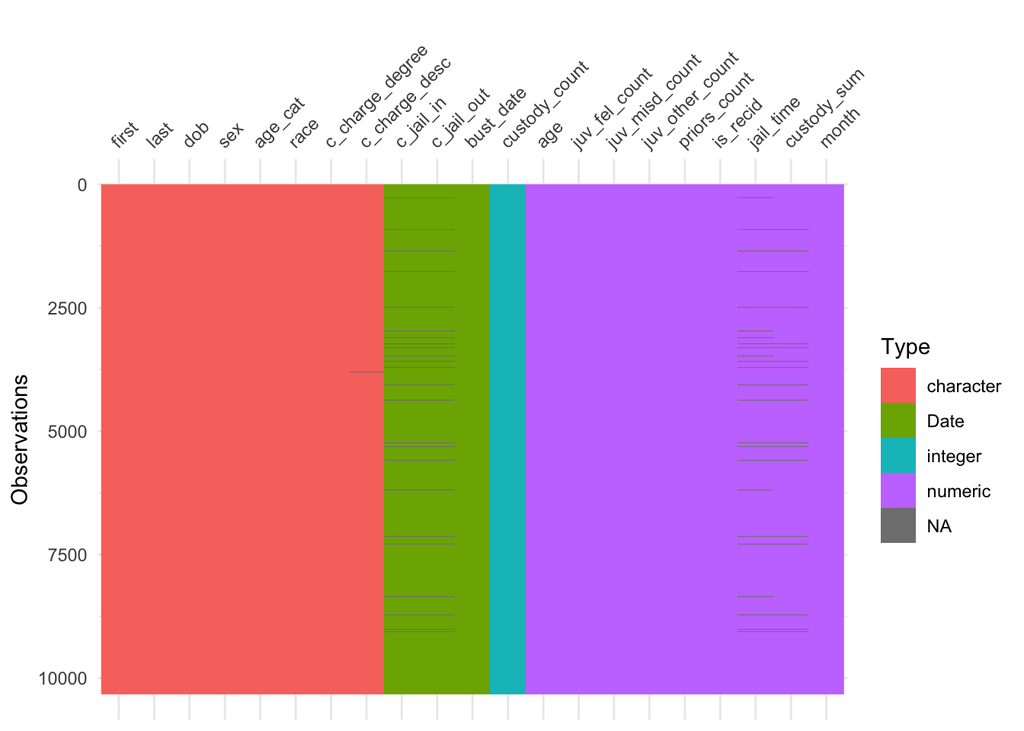

Na powyższym wykresie widać charakterystke typów zmiennych oraz niski udział braków danych w ramce.

## 3.2 Wykresy słupkowe

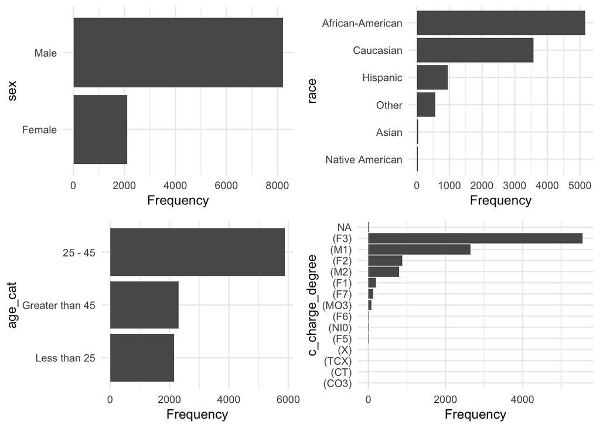

Prosta wizualizacja zmiennych kategorycznych, z której możemy dowiedzieć się, że większość przestępców z analizowanej ramki danych to mężczyźni, a najliczniejsza grupa rasowa to `African-American`. Większość rekordów to dane osób z przedziału wiekowego `25-45`, a najwięcej przestępstw to te 3 stopnia, czyli karane do 5 lat pozbawienia wolności.

## 3.3 Histogramy

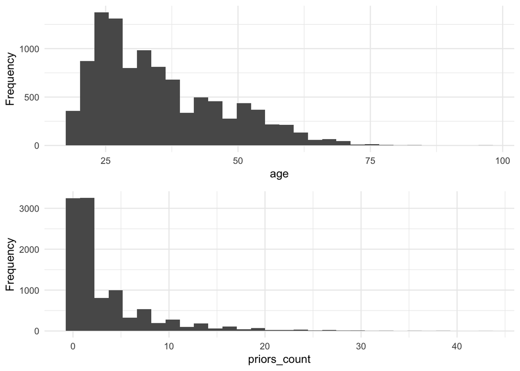

Na histogramach możemy zobaczyć dokładniejszy podział wiekowy, a także ilość wcześniejszych wykroczeń.

# 4 Zależności wśród danych

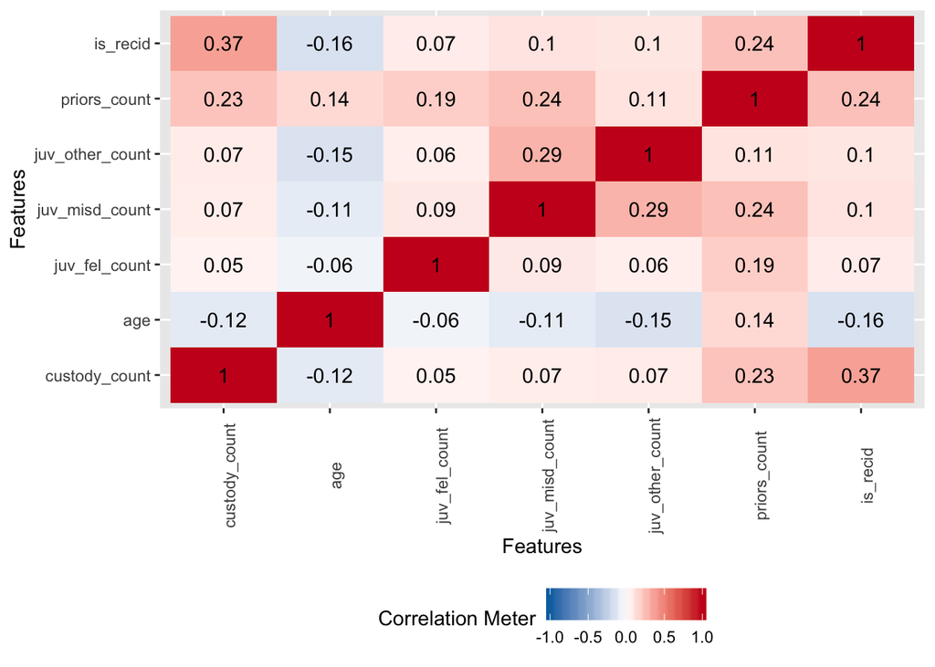

Wysoka korelacja występuje pomiędzy takimi zmiennymi jak `is_recid` i `custody_count` co może wskazywać na przydatność, wydobytej przez nas zależności w przewidywaniu szansy na powtórne popełnienie przestępstwa.

# 5 Głębsza analiza

## 5.1 Analiza dodanych kolumn:

### 5.1.1 `custody_count`

```
##    Min. 1st Qu.  Median    Mean 3rd Qu.    Max.
##   1.000   1.000   1.000   1.359   1.000  12.000
```

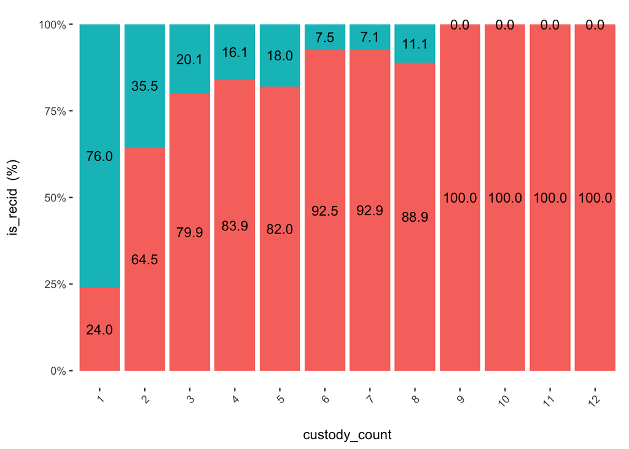

Dzięki temu można wykresowi zauważyć zależność między ilością pobytów w areszcie, a recydywą. Im więcej razy osoba była w areszcie, tym bardziej prawdopodobne jest to, że w końcu zostanie osadzona ponownie w więzieniu, fakt ten nie powinien nikogo zaskakiwać.

### 5.1.2 `custody_sum`

```
##    Min. 1st Qu.  Median    Mean 3rd Qu.    Max.    NA's
##     0.0     1.0     4.0   102.4    53.0  5782.0     326
```

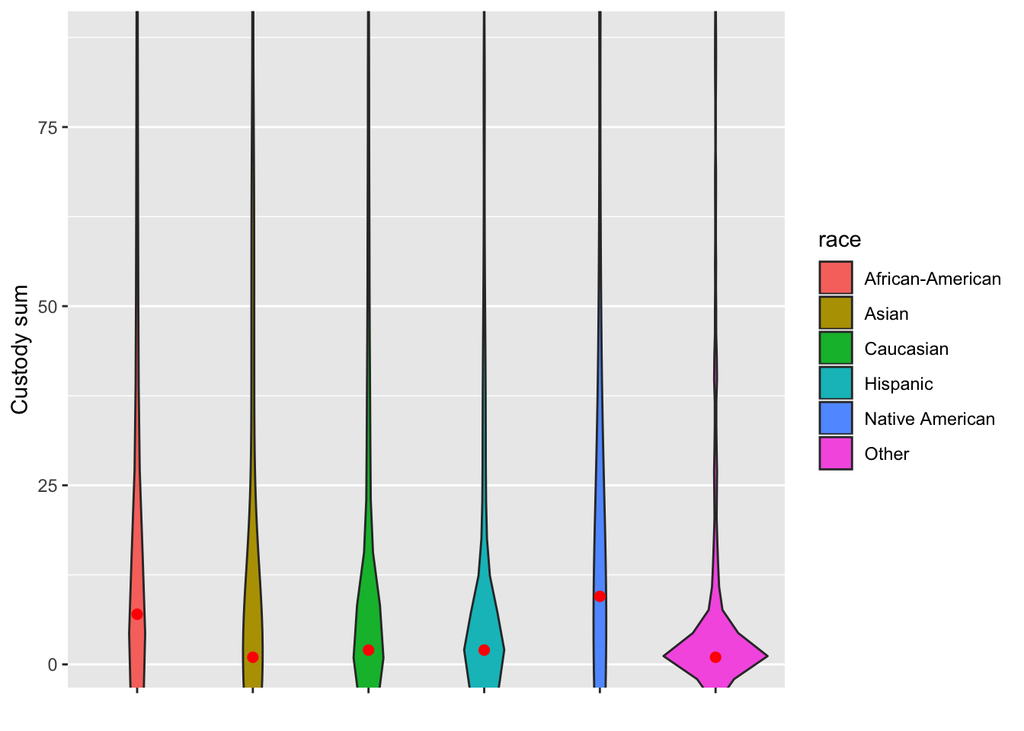

### 5.1.3 `jail_time`

```
##    Min. 1st Qu.  Median    Mean 3rd Qu.    Max.    NA's
##    0.00    1.00    1.00   25.35   13.00 2153.00     429
```

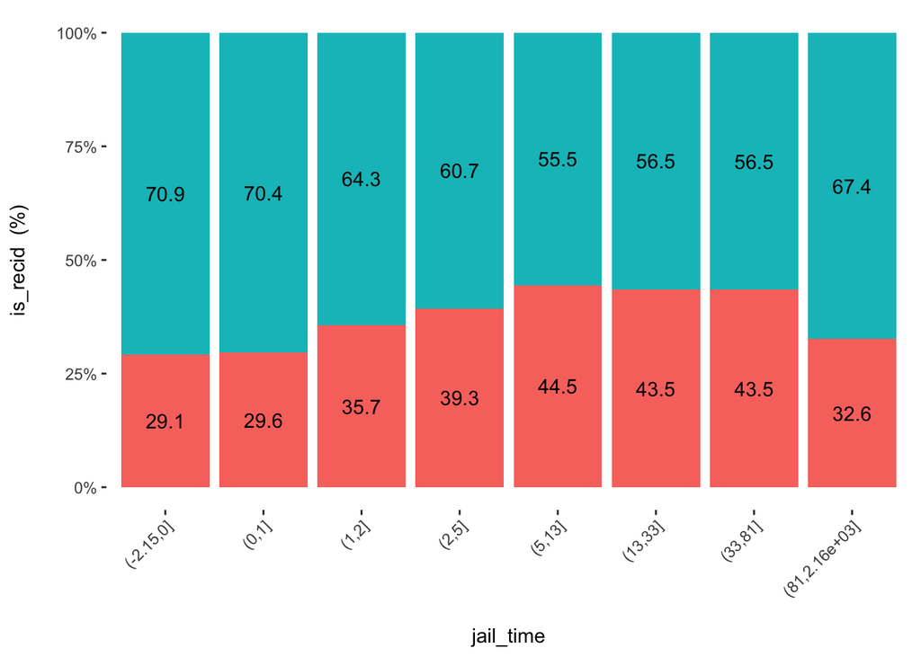

Na powyższym wykresie można zauważyć, że im dłuższy czas spędzony w więzieniu, tym większe szanse na recydywę, jednak ta tendencja się łamie przy dłuższych wyrokach. Aby dokładnie zrozumieć, co się dzieje przy dłuższych wyrokach trzeba wziąć pod uwagę, że aż **97%** wyroków ma długość poniżej 200 dni. Jednak jak przedstawiają się zależności dla tych dłuższych wyroków? Poniższy wykres to wyjaśni.

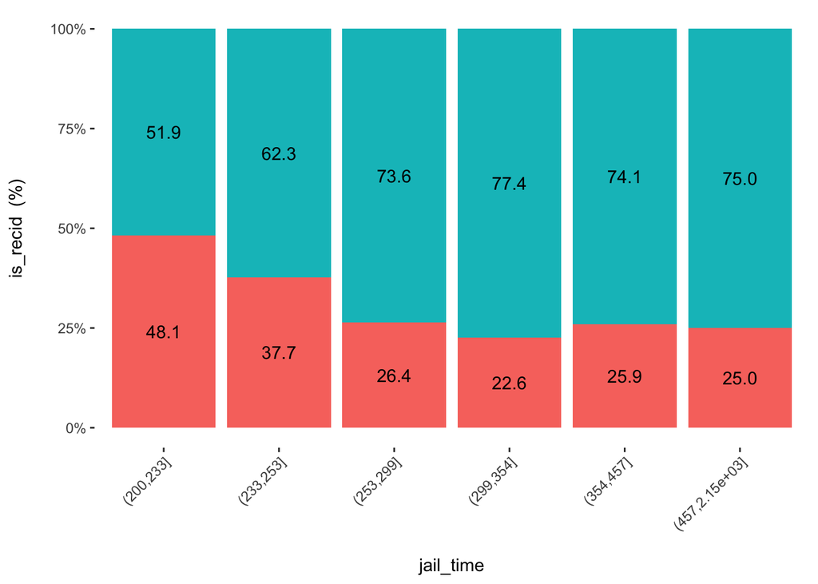

Można z tego wywnioskować, że osoby z wyrokami długości około 200 dni są najbardziej podatne na ponowne trafienie do więzienia. Dla wyroków powyżej tej wartości prawdopodobieństwo spada do około 25%.

## 5.2 Płeć i grupa rasowa

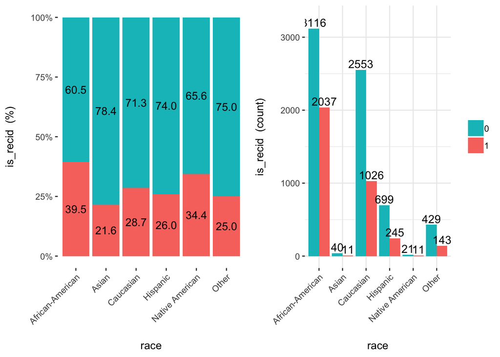

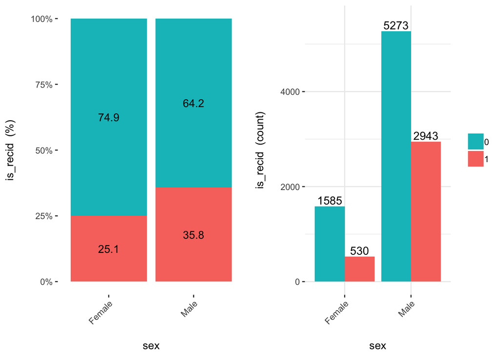

Najwięcej, a także stosunkowo najczęściej recydywistami okazują się przedstawiciele grupy `African-American`, a w podziale na płcie częściej wracają do więzenia mężczyźni.

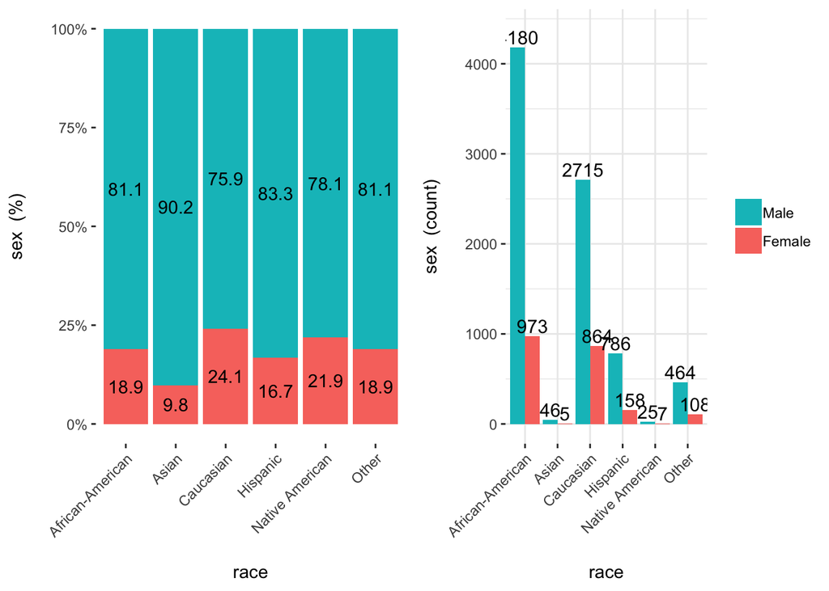

Najczęściej kobiety występują wśród grupy `Caucasian`, a najrzadziej wśród grupy `Asian`.

## 5.3 Przestępstwa

### 5.3.1 Najczęściej popełniane przestępstwa

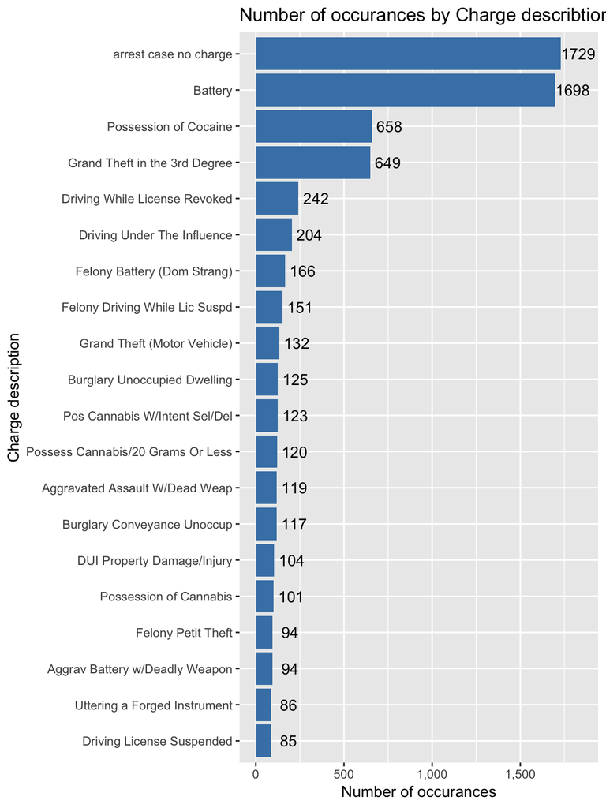

Przedstawione zostało 20 najczęściej występujących przestępstw.

### 5.3.2 Ilość recydywistów w czasie

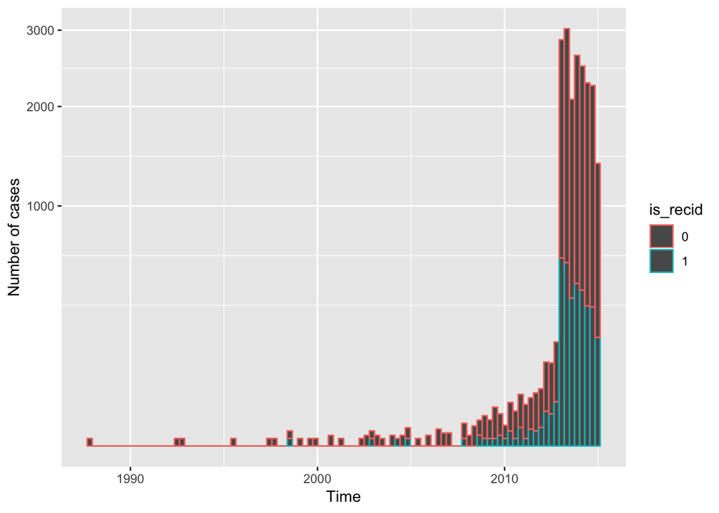

Jak widać na powyższym histogramie w ostanim czasie liczba recydywistów wykazuje tendencję spadkową.

### 5.3.3 Wiek i grupa rasowa

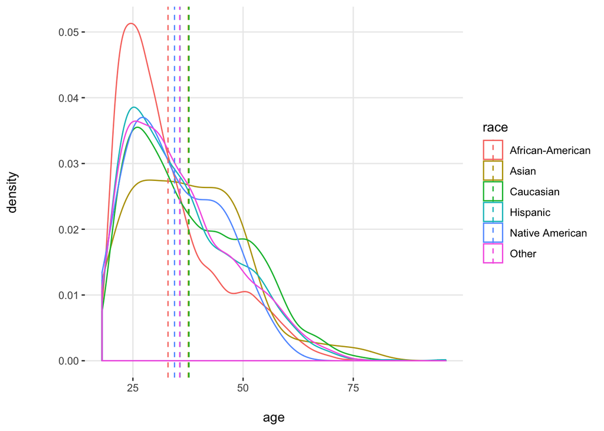

Ciekawą obserwacją jest to, że przedstawiciele grupy `Asian` nie mają charakterystycznego dla innych grup piku w okolicy wieku `25 lat`.

### 5.3.4 Ilość przestępstw w czasie

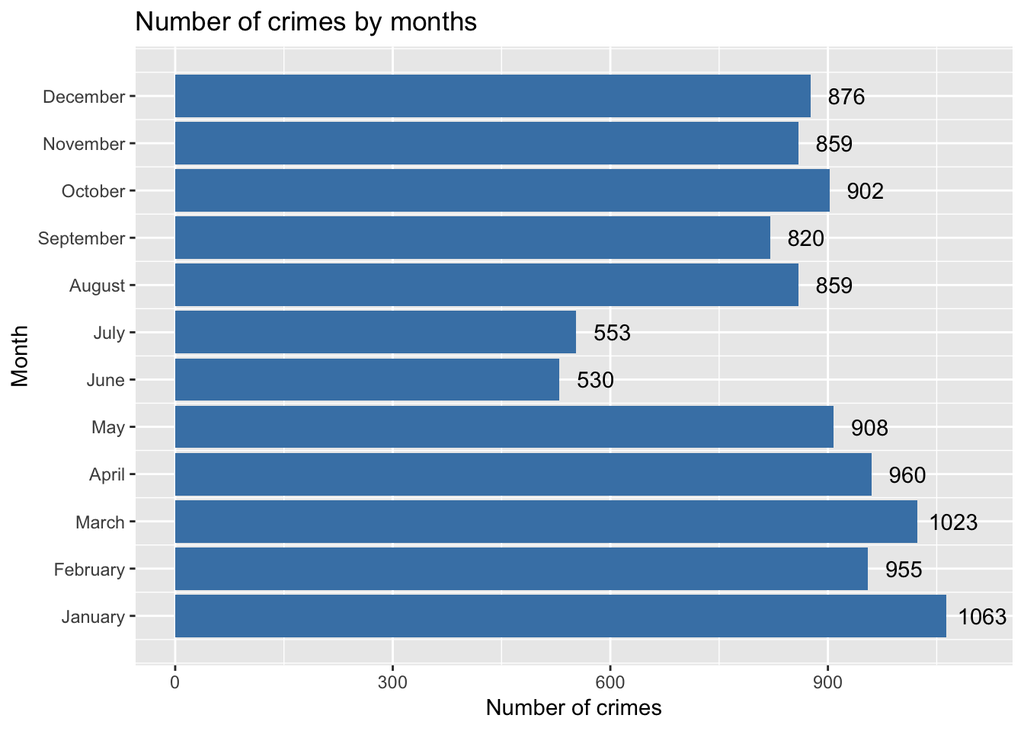

Widać tu dwie ciekawe własności, jedna jest taka, że na początku roku jest popełniane więcej zbrodni, a drugą jest znaczący spadek przestępczości w okresie wakacje letnich.

### 5.3.5 Wpływ czasu pobydu w więzieniu i ilości pobytów w areszcie na bycie recydiwistą

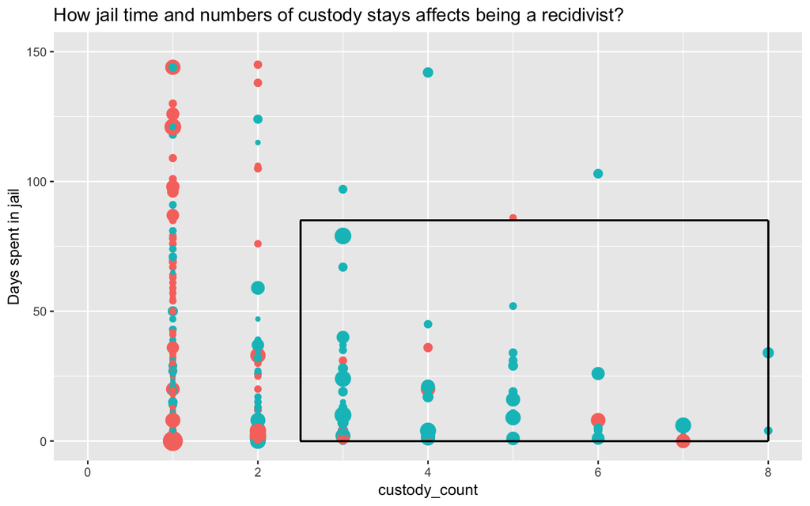

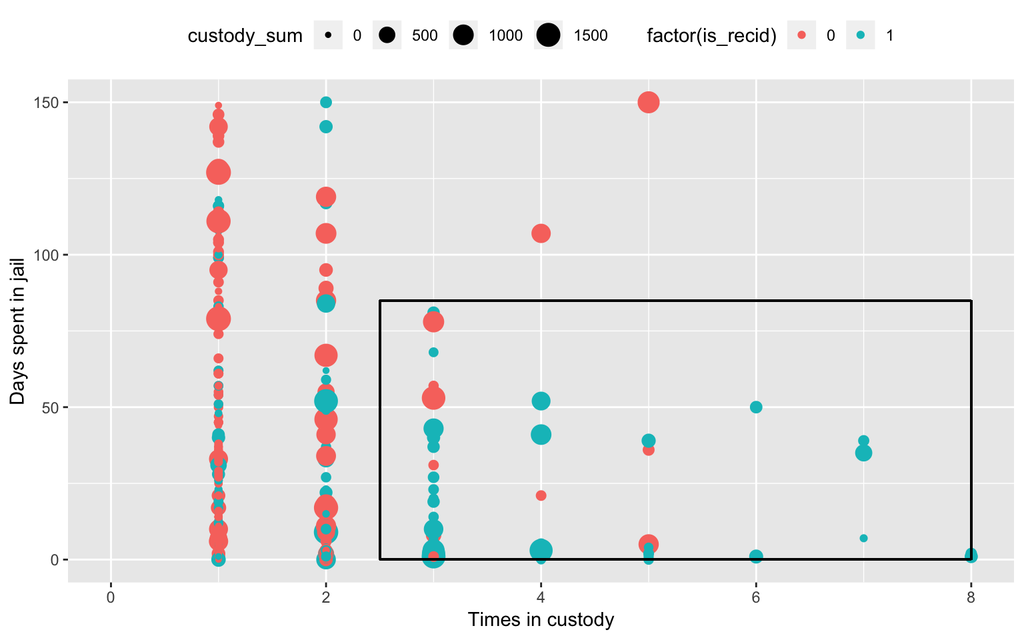

Z tego wykresu można odczytać, że im więcej ludzie spędzili w więzieniu tym rzadziej tam wracają. Widać również na zaznaczonym prostokącie, że im osoba więcej razy była w areszcie większe szanse, że zostanie recydiwistą.